# Speed-Acc Noise Gaze Analysis

Kyle MacDonald

## Set up

Here are some helpful links for understanding the workflow for analyzing data in R Markdown (what you’re doing in this document!):

- [Scripts](http://r4ds.had.co.nz/workflow-scripts.html)
- An R Markdown [guide](https://docs.google.com/document/d/1ajv1VJqEheVws93tnzH-K7145vBKtwD3Az5pg3faRdw/edit?usp=sharing) that I wrote for the lab

```r
# read in personal library of helper functions
source("../../helper_functions/libraries_and_functions.R")
```

## Load data

Section 11.2 from [this](http://r4ds.had.co.nz/data-import.html) chapter on data importing is great.

**KM note**: this way of reading the file will work, but it only will work on your computer since this part of the path [~/Desktop/Research/] is specific to where you saved the data. The solution is to use a relative path like I’ve done here. You can check out this [video](https://www.youtube.com/watch?v=fe6GA200dks) for more background.

```r
# read in the data using a relative path that starts from the analysis file directory
d <- read_csv("../../../data/3_final_merged_data/first_shifts/speed_acc_adult_ng_fstshift_tidy.csv")
```

## Check the data

[This](http://r4ds.had.co.nz/transform.html) chapter from the book **R for Data Science** is a good reference for writing code to manipulate data to do data “sanity” checks.

How many participants in the dataset?

**KM note**: Nice work on the checks! It made me catch a few errors in my data processing pipeline. Note that you could also write these series of commands as connected using pipes. Check [this](http://r4ds.had.co.nz/pipes.html) out for more information.

```r
by_id <- group_by(d, subid)
summary_by_id <- summarise(.data = by_id)
count(summary_by_id)
```

```
## # A tibble: 1 x 1
##       n
##   <int>
## 1    11
```

How many trials do we have for each participant?

```r
by_trial <- group_by(d, subid, tr.num)
summary_by_trial <- summarise(.data = by_trial)
count(summary_by_trial)
```

```
## # A tibble: 11 x 2
## # Groups:   subid [11]
##                    subid     n
##                    <chr> <int>
##  1  speed_acc_adult_ng_1    64
##  2 speed_acc_adult_ng_10    64
##  3 speed_acc_adult_ng_11    60
##  4  speed_acc_adult_ng_2    64
##  5  speed_acc_adult_ng_3    64
##  6  speed_acc_adult_ng_4    64
##  7  speed_acc_adult_ng_5    64
##  8  speed_acc_adult_ng_6    64
##  9  speed_acc_adult_ng_7    64
## 10  speed_acc_adult_ng_8    25
## 11  speed_acc_adult_ng_9    63
```

**Km note**: Looks like there are only 25 trials for *speed_acc_adult_ng-8*. Not sure what’s going on?

How many trials in each condition?

```r
by_gaze_condition <- group_by(d, gaze_condition, subid, tr.num)
summary_by_gaze_condition <-summarise(.data = by_gaze_condition)
count(summary_by_gaze_condition)
```

```
## # A tibble: 22 x 3
## # Groups:   gaze_condition, subid [22]
##    gaze_condition                 subid     n
##             <chr>                 <chr> <int>
##  1           gaze  speed_acc_adult_ng_1    32
##  2           gaze speed_acc_adult_ng_10    32
##  3           gaze speed_acc_adult_ng_11    32
##  4           gaze  speed_acc_adult_ng_2    32
##  5           gaze  speed_acc_adult_ng_3    32
##  6           gaze  speed_acc_adult_ng_4    32
##  7           gaze  speed_acc_adult_ng_5    32
##  8           gaze  speed_acc_adult_ng_6    32
##  9           gaze  speed_acc_adult_ng_7    32
## 10           gaze  speed_acc_adult_ng_8     9
## # ... with 12 more rows
```

```r
by_noise_condition <- group_by(d, noise_condition, subid, tr.num)
summary_by_noise_condition <-summarise(.data = by_noise_condition)
count(summary_by_noise_condition)
```

```
## # A tibble: 21 x 3
## # Groups:   noise_condition, subid [21]
##    noise_condition                 subid     n
##              <chr>                 <chr> <int>
##  1        no_noise  speed_acc_adult_ng_1    32
##  2        no_noise speed_acc_adult_ng_10    32
##  3        no_noise speed_acc_adult_ng_11    28
##  4        no_noise  speed_acc_adult_ng_2    32
##  5        no_noise  speed_acc_adult_ng_3    32
##  6        no_noise  speed_acc_adult_ng_4    32
##  7        no_noise  speed_acc_adult_ng_5    32
##  8        no_noise  speed_acc_adult_ng_6    32
##  9        no_noise  speed_acc_adult_ng_7    32
## 10        no_noise  speed_acc_adult_ng_9    32
## # ... with 11 more rows
```

**KM note**: Looks like we need to create a single variable that stores information about both the noise and gaze condition.

```r
d <- d %>% mutate(condition_long = paste(gaze_condition, noise_condition, sep = "_"))
```

**KM note**: Now we can see how many trials are in each condition.

```r
d %>%
  group_by(subid,condition_long) %>%
  summarise(n = n()) %>%
  kable()
```

| subid | condition_long | n |
| --- | --- | --- |
| speed_acc_adult_ng_1 | gaze_no_noise | 16 |
| speed_acc_adult_ng_1 | gaze_noise | 16 |
| speed_acc_adult_ng_1 | no_gaze_no_noise | 16 |
| speed_acc_adult_ng_1 | no_gaze_noise | 16 |
| speed_acc_adult_ng_10 | gaze_no_noise | 16 |
| speed_acc_adult_ng_10 | gaze_noise | 16 |
| speed_acc_adult_ng_10 | no_gaze_no_noise | 16 |
| speed_acc_adult_ng_10 | no_gaze_noise | 16 |
| speed_acc_adult_ng_11 | gaze_no_noise | 16 |
| speed_acc_adult_ng_11 | gaze_noise | 16 |
| speed_acc_adult_ng_11 | no_gaze_no_noise | 12 |
| speed_acc_adult_ng_11 | no_gaze_noise | 16 |
| speed_acc_adult_ng_2 | gaze_no_noise | 16 |
| speed_acc_adult_ng_2 | gaze_noise | 16 |
| speed_acc_adult_ng_2 | no_gaze_no_noise | 16 |
| speed_acc_adult_ng_2 | no_gaze_noise | 16 |
| speed_acc_adult_ng_3 | gaze_no_noise | 16 |
| speed_acc_adult_ng_3 | gaze_noise | 16 |
| speed_acc_adult_ng_3 | no_gaze_no_noise | 16 |
| speed_acc_adult_ng_3 | no_gaze_noise | 16 |
| speed_acc_adult_ng_4 | gaze_no_noise | 16 |
| speed_acc_adult_ng_4 | gaze_noise | 16 |
| speed_acc_adult_ng_4 | no_gaze_no_noise | 16 |
| speed_acc_adult_ng_4 | no_gaze_noise | 16 |
| speed_acc_adult_ng_5 | gaze_no_noise | 16 |
| speed_acc_adult_ng_5 | gaze_noise | 16 |
| speed_acc_adult_ng_5 | no_gaze_no_noise | 16 |
| speed_acc_adult_ng_5 | no_gaze_noise | 16 |
| speed_acc_adult_ng_6 | gaze_no_noise | 16 |
| speed_acc_adult_ng_6 | gaze_noise | 16 |
| speed_acc_adult_ng_6 | no_gaze_no_noise | 16 |
| speed_acc_adult_ng_6 | no_gaze_noise | 16 |
| speed_acc_adult_ng_7 | gaze_no_noise | 16 |
| speed_acc_adult_ng_7 | gaze_noise | 16 |
| speed_acc_adult_ng_7 | no_gaze_no_noise | 16 |
| speed_acc_adult_ng_7 | no_gaze_noise | 16 |
| speed_acc_adult_ng_8 | gaze_noise | 9 |
| speed_acc_adult_ng_8 | no_gaze_noise | 16 |
| speed_acc_adult_ng_9 | gaze_no_noise | 16 |
| speed_acc_adult_ng_9 | gaze_noise | 16 |
| speed_acc_adult_ng_9 | no_gaze_no_noise | 16 |
| speed_acc_adult_ng_9 | no_gaze_noise | 15 |

TODO: Check out what’s going on with #8

## Explore data via visualization

[This](http://r4ds.had.co.nz/data-visualisation.html) is a great book chapter on data visualization using the ggplot2 R package

### Visualize data distributions

My goal when I visualize the distribution of a variable is usually to check if there any data points that look like outliers (really different from the other values in the sample). There are more precise, quantitative ways to define outlier, but the visualization helps us spot them quickly. If some observations look really different, I then try to reason about why that might be the case: data entry error? equipment measurement error?

What about Reaction Times (RT)?

**KM note**: Nice job! Small point, but there’s no need to load the library in each chunk. Just need to do it once, which we usually do at the beginning of the document. Also, there’s no need to wrap the `d` object in the `data.frame()` function since it is already a data frame.

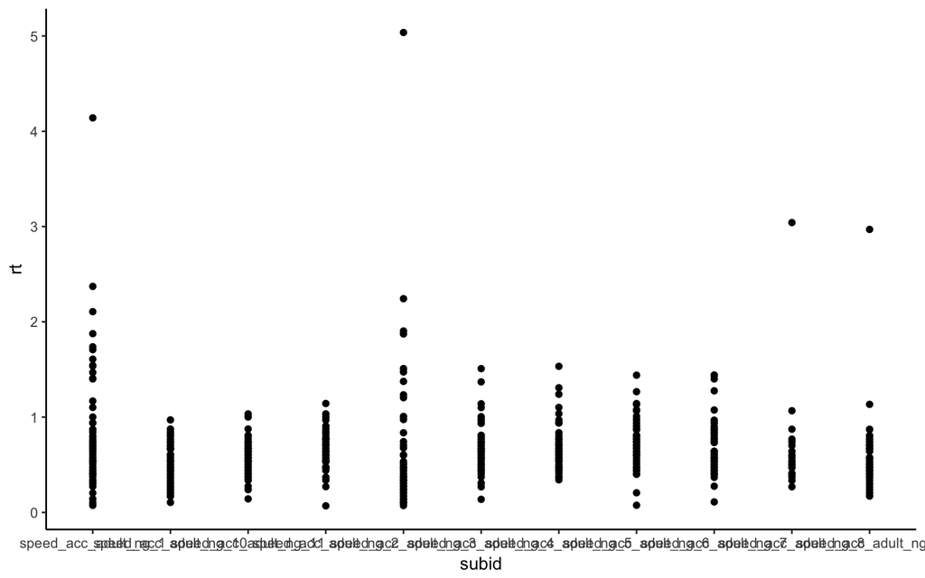

```r
#data.frame(d)
ggplot(d) +
  geom_point(mapping = aes(x = subid, y = rt))
```

`geom_histogram()` is a good one for viewing the overall distribution of RTs in the experiment.

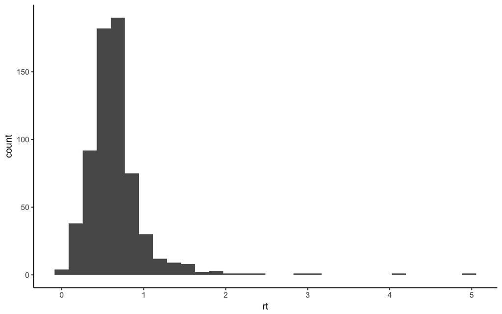

```r
ggplot(d, aes(x = rt)) +
  geom_histogram()
```

What about Accuracy?

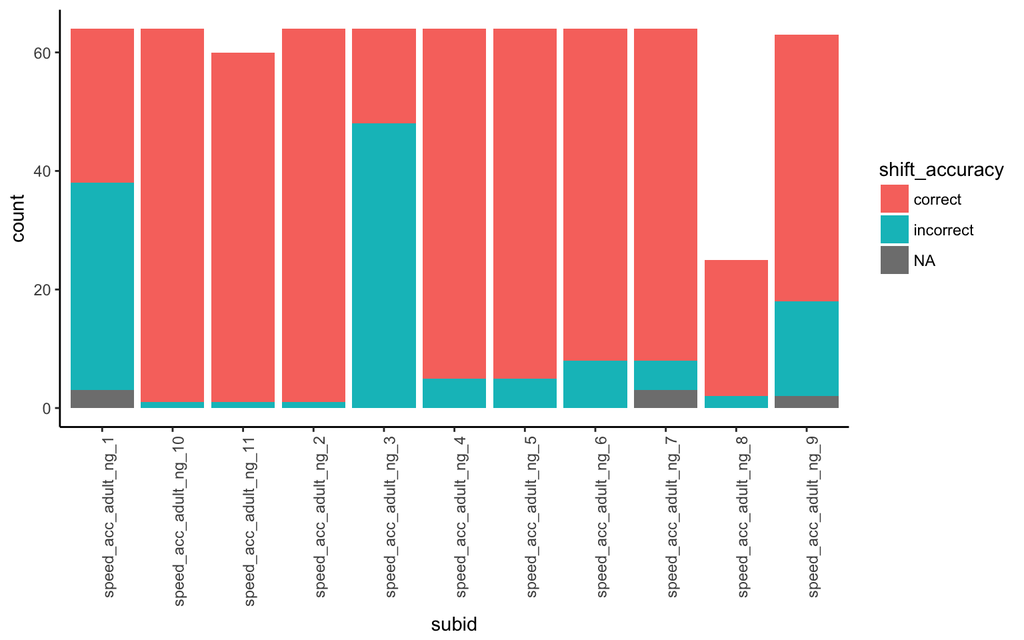

```r
ggplot(d) +
  geom_bar(mapping = aes(x = subid, fill = shift_accuracy)) +
  theme(axis.text.x = element_text(angle = 90, hjust = 1))
```

**KM note**: This is a great exploratory plot! We can see that a couple of participants are doing “weird” things that we would want to investigate further. The only thing I changed was the angle of the x-axis text, so we can see the subids more easily.

## filter the data

Let’s filter out the participants who was not a native speaker of English

```r
d.filt <- d %>% filter(!(subid %in% c("speed_acc_adult_ng_1")))
```

Next, let’s remove extreme RTs.

```r
d.filt %<>% filter(rt <= 1.5)
```

### Visualize Accuracy

What is the overall accuracy of first shifts?

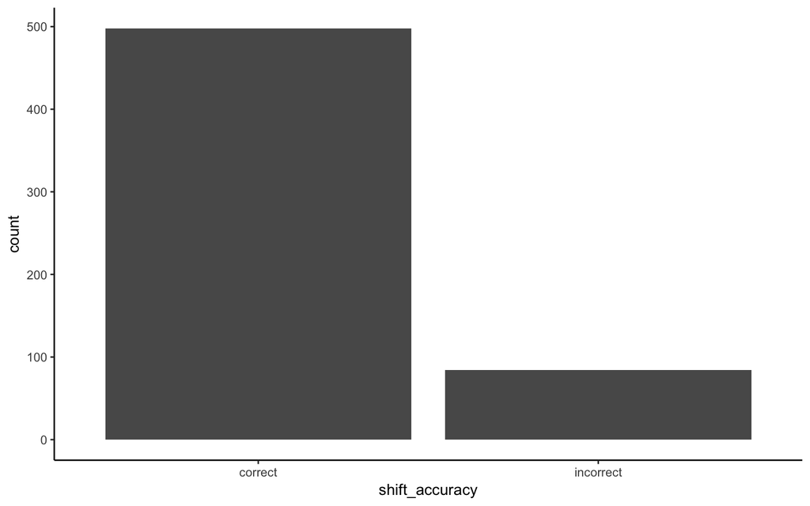

```r
ggplot(d.filt) +
  geom_bar(mapping = aes(x = shift_accuracy))
```

What about the accuracy for each condition?

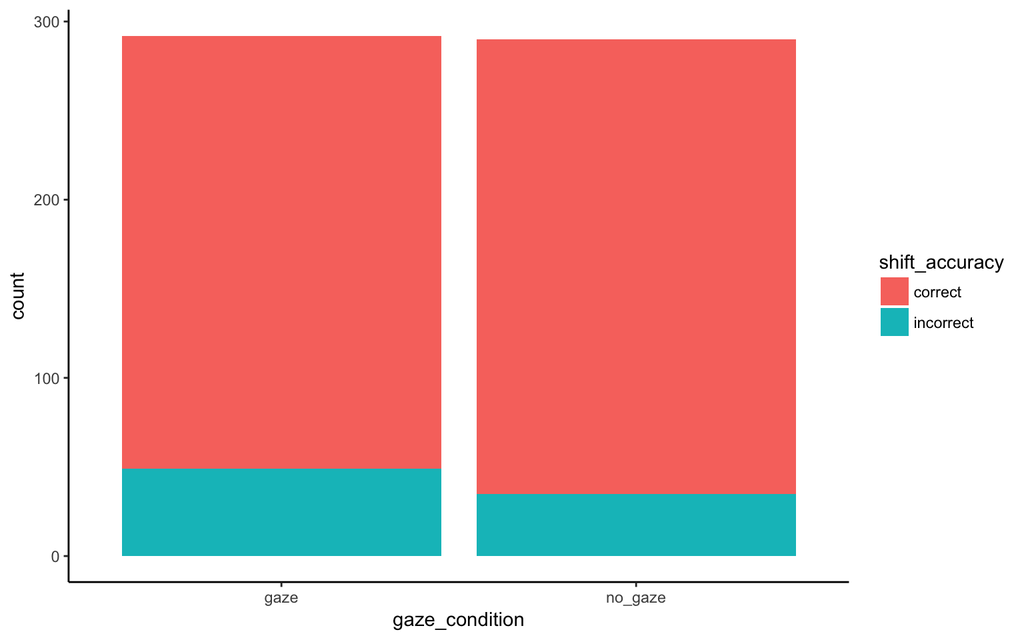

```r
ggplot(d.filt) +
  geom_bar(mapping = aes(x = gaze_condition, fill = shift_accuracy))
```

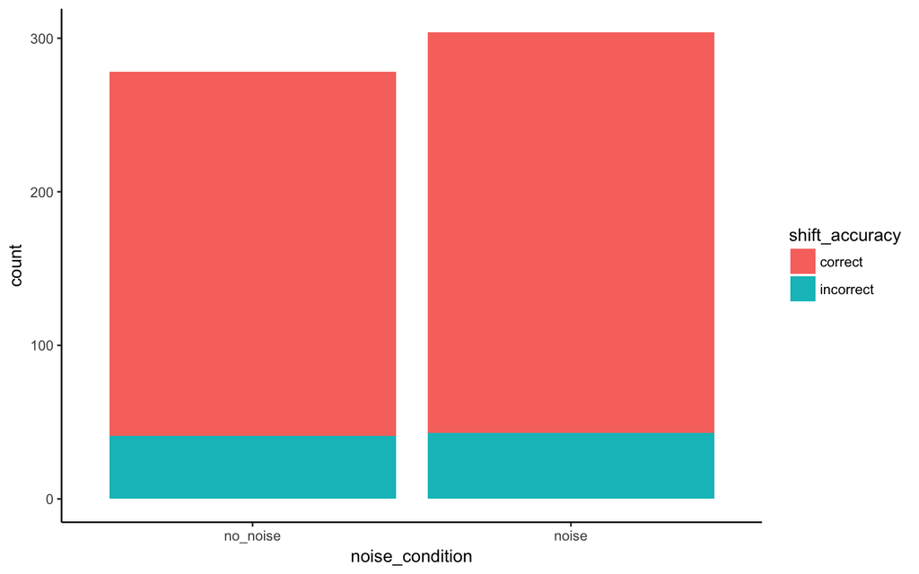

```r
ggplot(d.filt) +
  geom_bar(mapping = aes(x = noise_condition, fill = shift_accuracy))
```

**KM code after here**

Let’s visualize accuracy collapsing across the gaze and noise conditions. First we are going to summarise to get a proportion correct for each participant and condition. Then we aggregate again to get an overall proportion correct for each condition.

```r
# aggregate accuracy at the participant level
ss <- d.filt %>%
  filter(!is.na(shift_accuracy),
         shift_type %in% c("C_T", "C_D")) %>%
  group_by(condition_long, subid, shift_accuracy) %>%
  summarise(n = n()) %>%
  group_by(subid, condition_long) %>%
  mutate(total_trials = sum(n),
         prop = round(n / total_trials, 2))

# aggregate at the condition level
ms <- ss %>%
  filter(shift_accuracy == "correct") %>%
  group_by(condition_long) %>%
  multi_boot_standard(column = "prop")
```

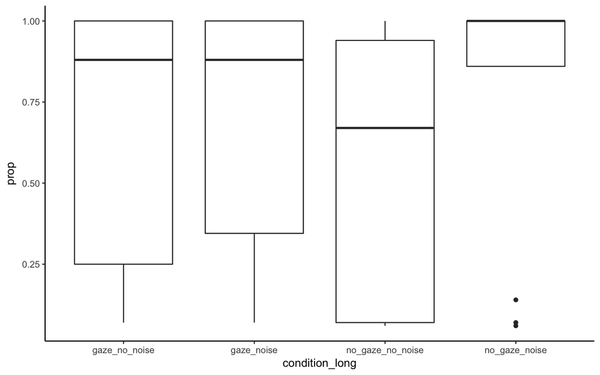

```r
ss %>%
  ggplot(aes(x = condition_long, y = prop)) +
  geom_boxplot()
```

Plot the mean accuracy and confidence interval for each condition.

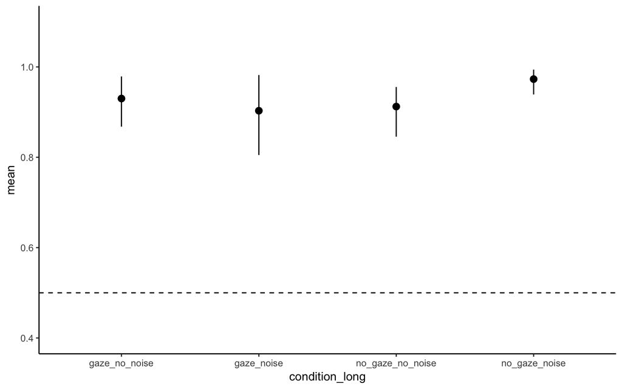

```r
ms %>%
  ggplot(aes(x = condition_long, y = mean)) +
  geom_pointrange(aes(ymin = summary_ci_lower, ymax = summary_ci_upper)) +
  ylim(0.4, 1.1) +
  geom_hline(yintercept = 0.5, linetype = "dashed")
```

What is the overall RT for adults in the experiment?

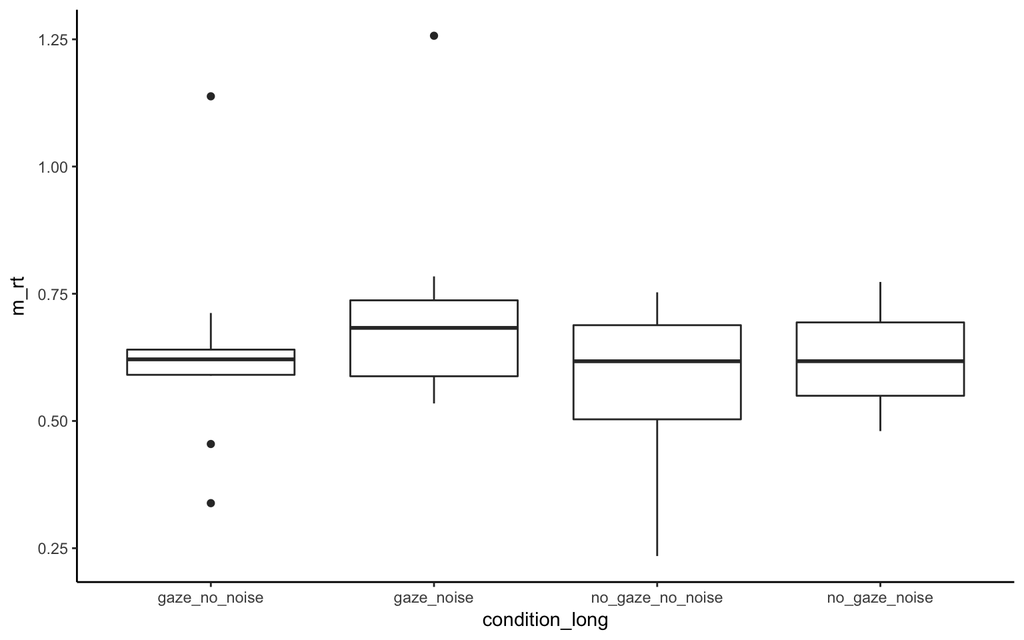

```r
d %>%
  filter(!is.na(shift_accuracy),
          shift_type %in% c("C_T", "C_D")) %>%
  group_by(subid, condition_long) %>%
  summarise(m_rt = mean(rt)) %>%
  ggplot(aes(x = condition_long, y = m_rt)) +
  geom_boxplot()
```

What about RTs for correct vs. incorrect shifts?

```r
rr <- d %>%
  filter(!is.na(shift_accuracy)) %>% # remove trials where they did not shift
  group_by(condition_long, subid, shift_accuracy, rt) %>%
  summarise(n = n()) %>%
  group_by(subid, condition_long)

# aggreate at the condition level(correct)
rs <- rr %>%
  filter(shift_accuracy == "correct") %>%
  group_by(condition_long) %>%
  summarise(mean_correct = mean(rt),
            sd_correct = sd(rt))

# aggreate at the condition level(incorrect)
rk <- rr %>%
  filter(shift_accuracy == "incorrect") %>%
  group_by(condition_long) %>%
  summarise(mean_correct = mean(rt),
            sd_correct = sd(rt))
```

Boxplot

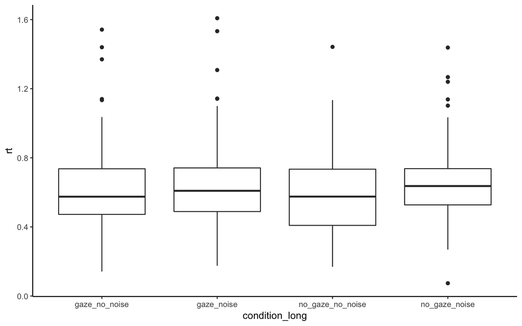

```r
rr %>%
  filter(shift_accuracy == "correct") %>%
  ggplot(aes(x = condition_long, y = rt)) +
  geom_boxplot()
```

## RT Distributions

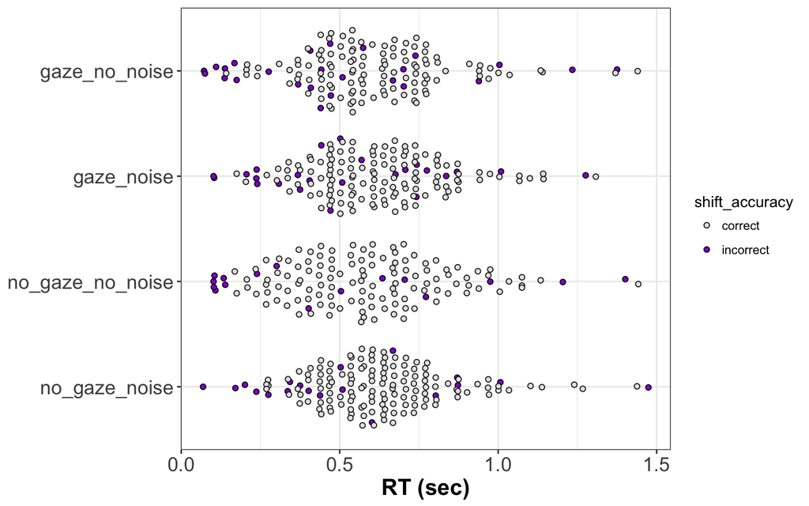

```r
acc_colors <- c("grey10", "black")
fill_vals <- c("grey90", "darkviolet")

p <- d.filt %>%
  filter(is.na(rt) == F) %>%
  ggplot(aes(x = forcats::fct_rev(condition_long), y = rt, color = shift_accuracy,
             fill = shift_accuracy)) +
  ggbeeswarm::geom_quasirandom(shape = 21) +
  scale_color_manual(values = acc_colors) +
  scale_fill_manual(values = fill_vals) +
  labs(y = "RT (sec)", x = NULL) +
  theme_bw() +
  theme(legend.position = "right") +
  theme(axis.title.x = element_text(size = 16,
                                    face = "bold"),
        axis.title.y = element_text(size = 16,
                                    face = "bold"), axis.text.x = element_text(size = 14),
        axis.text.y = element_text(size = 14)) +
  coord_flip()

p
```

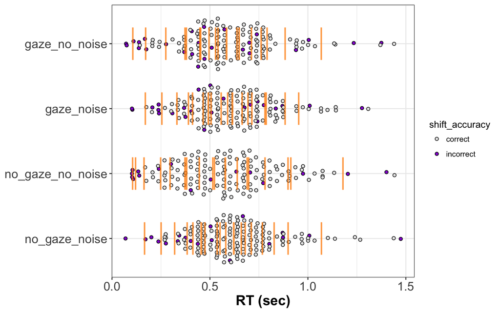

```r
rogme::plot_dec_bars(p, col = "darkorange", dec_size = 0.8, alpha = 0.5)
```

## Statistical models

We can talk more about this aspect of the anlaysis once you made some progress on data viz.